# R Jam Sessions Vol.3

Juan C. Sanchez-Arias

2020-07-21

## About Vol.3

I got a puppy! Her name is Luna (*latin* for Moon) and she is a 12 week Shel-Aussie (Shetland Shepherd x Australian Shepherd mix). so far Luna seems to be a very sweet, playful, and smart dog, but I guess this is what everyone says about their dogs. I have had some other dogs in the past (a rottie and two miniature poodles, one white and one black) and I also thought they were quite smart. so I wanted to learn more about how other breedsd perform in “intelligence tasks”.

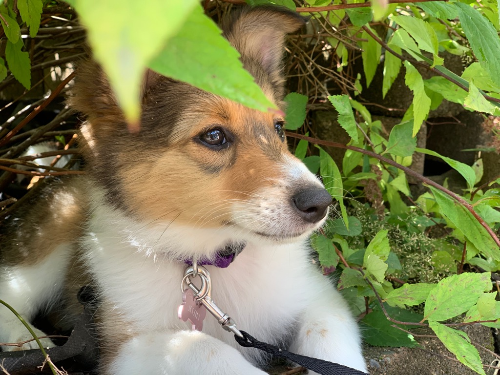

Luna: “Hello world!”

Luckily, I found some dataasets that will help me endorse my curiosity. The datasets are:

- Intelligence of Dogs:
  - Source: https://data.world/len/intelligence-of-dogs
  - This dataset is based on research by Stanley Coren, a professor of canine psychology at the University of British Columbia. When Coren first published his book in 1994, there was a high degree of dispute of his analysis, though over time his work has been largely accepted.
    - Data Dictionary
    - obey: probability that the breed obeys the first command (figure is lower bound)
    - reps_lower: lower limit of repetitions to understand new commands
    - reps_upper: upper limit of repetitions to understand new commands
  - More info: https://en.m.wikipedia.org/wiki/The_Intelligence_of_Dogs#cite_ref-ReferenceA_18-0
- Dog Breedn size (AKC recrods)
  - Source: https://data.world/len/dog-canine-breed-size-akc

### Size

Checking size charactersitics in this AKC dataset

#### By weight

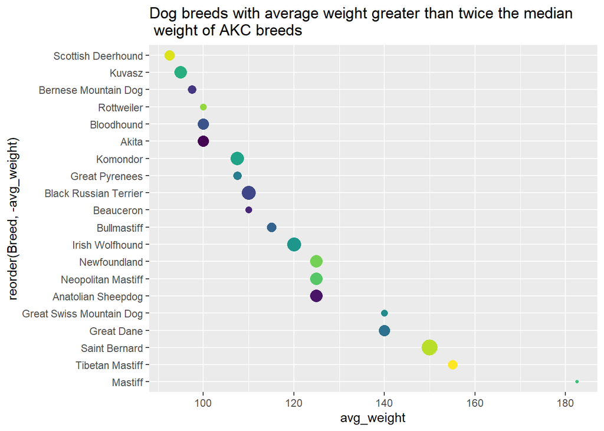

```r
variable_units <- data.frame(var_name = c("Weight", "Height"), units = c("lb", "in"))
variable_units
```

```
##   var_name units
## 1   Weight    lb
## 2   Height    in
```

#### By height

[figure not shown]

## R Jam Sessions Schedule

| Date | R Jam Topic | Relevant Links |
| --- | --- | --- |
| 2020-05-26 | [Vol.1: Exploring some genes in the developmental brain transcriptome map - brain-span](https://juansamdphd.github.io/rjam/vol_1) | [**Brain**span](http://www.brainspan.org/rnaseq/search/index.html) |
| 2020-06-12 | [Vol.2: Explore Cali, ve!](https://juansamdphd.github.io/rjam/vol_2) | [Datos Abiertos](http://datos.cali.gov.co/) - Cali |
| 2020-07-21 | [Vol.3: I got a puppy!](https://juansamdphd.github.io/rjam/vol_3) | [data.world](https://data.world/len/intelligence-of-dogs) |